# Bivariate Data

## Statistic Class Week 4

[figure not shown]

### Bivariate Data

- Scatter plots
- Correlation
- Regression
  - Linear
  - Nonlinear

## Chapter 5 - Bivariate Data

## Terms Review

A **bivariate** data set consists of observations on two variables made on individuals in a sample or population. A *scatterplot* is a plot of pairs of observed values (both quantitative) of two different variables

- A **response variable** is thought to be related to the explanatory variable in the experiment, but not controlled by the experimenter. In a bivariate data set this is called the **dependent variable** and is the value we would like to predict. The dependent variable is denoted by y.
- An **explanatory variable** are those variables that have values that are controlled by the experimenter. Also called factors. In a bivariate data set this is called the **independent variable** or **predictor variable** and is used to make a prediction of the dependent variable. The independent variable is denoted by x.

## Association

**Positive Association** - Two variables are positively associated when above-average values of one tend to accompany above-average values of the other and below-average values tend similarly to occur together. (i.e., Generally speaking, the y values tend to increase as the x values increase.)

**Negative Association** - Two variables are negatively associated when above-average values of one accompany below-average values of the other, and vice versa. (i.e., Generally speaking, the y values tend to decrease as the x values increase.)

## Correlation Coeficient

Pearson **Correlation Coefficient** is a measure of the strength of the linear relationship between the two variables is called the Pierson correlation coefficient.

The Pearson sample correlation coefficient is defined by

\[r = r_{xy} = \frac{\sum (Z_x Z_y)}{n-1} = \frac{1}{n-1} \sum ^n _{i=1} \left( \frac{x_i - \bar{x}}{s_x} \right) \left( \frac{y_i - \bar{y}}{s_y} \right)\]

## Correlation Coeficient Example

The sum of the product of Z is 8.5 divided by 9 to get r = 0.95

```r
cor(x,y)
```

```
## [1] 0.9468211
```

## Correlation

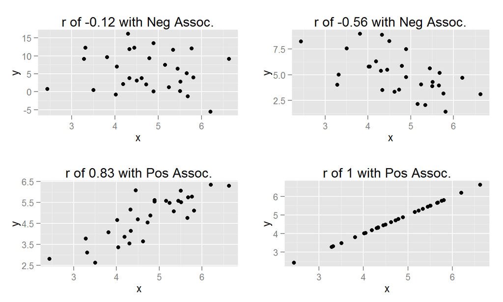

## Properties of r

- The value of r does not depend on the unit of measurement for each variable.
- The value of r does not depend on which of the two variables is labeled x.
- The value of r is between -1 and +1.
- The correlation coefficient is
  - -1 only when all the points lie on a downward-sloping line, and
  - +1 only when all the points lie on an upward-sloping line.
- The value of r is a measure of the extent to which x and y are linearly related.

## Correlations

Correlation coefficient

- Advantage - Provides a quantitative measure of the degree of relatedness between two variables
- Disadvantage - Not very effective for non linear relationships

Scatter plot

- Advantages - Instantly shows the relationship between two variables
- Disadvantages - The relationship is described by a bunch of data points

Next step is a line to represent the data

## Linear regression

Object of a regression analysis is to use information about one variable, x, predict the value of a second variable, y. Multiple regression uses multiple variables to predict y.

The relationship **y = a + bx** is the equation of a straight line.

- The value **b**, called the slope of the line, is the amount by which y increases when x increase by 1 unit.
- The value of **a**, called the intercept (or sometimes the vertical intercept) of the line, is the height of the line above the value x = 0.

## Least Squares Line

The most widely used criterion for measuring the goodness of fit of a line  
**y = a + bx** to bivariate data \((x1, y1), (x2, y2),(xn,yn)\) is the sum of the of the squared deviations about the line.

\[SSD = \sum ^n _{i=1} (y_i - (a - bx_i))^2\]

The line that gives the best fit to the data is the one that minimizes this sum; it is called the **least squares** line or **sample regression** line.

## Calculating Least Squares Line

The equation is represented by **\(\hat{y} = a + bx\)** where

- Slope of \(b = \frac{1}{\sum (x -\bar{x})^2} \sum ((x -\bar{x})(y -\bar{y}))\)
- Intercept of \(a = \bar{y} - b\bar{x}\)

## Simple Regression Line Example

\[\hat{y} = 8.85 + 1.941 * x\]

## Example plot with regression

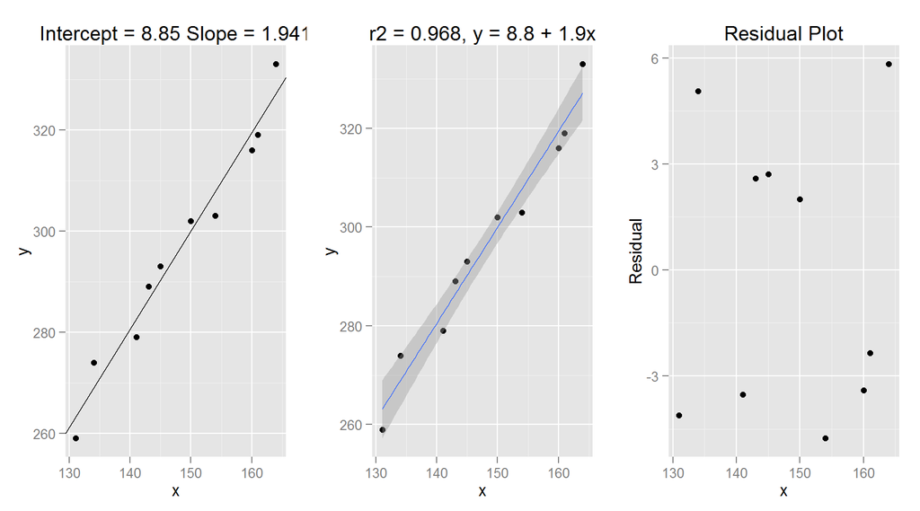

## Assessing the fit of a line

The **predicted** or **fitted** values result form substituting each sample x value into the equation for the least squares line. This gives

\[\hat{y}_1 = a + bx_1 = \text{1st predicted value}\] \[\hat{y}_2 = a + bx_2 = \text{2nd predicted value}\] \[\hat{y}_n = a + bx_n = \text{nth predicted value}\]

The **residuals** for the least squares line are the values: \(y_1-\hat{y}_1, y_2-\hat{y}_2,...,y_2-\hat{y}_2\)

## Residual Plot

A **residual plot** is a scatter plot of the data pairs (x, residual).

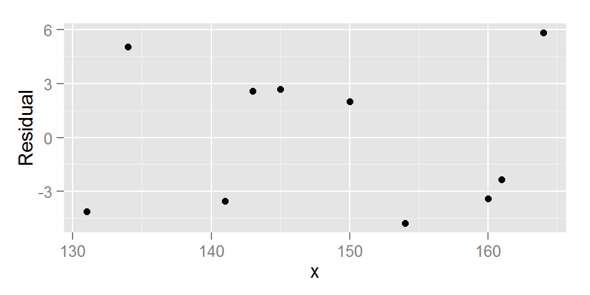

- Isolated points or patterns indicate potential problems
- Ideally the the points should be randomly spread out above and below zero.
- Patterns, such as curves or waves, indicate a nonlinear regression model
- Values below 0 indicate over predication

## Coefficient of determination

The **coefficient of determination**, denoted by \(r^2\), gives the proportion of variation in y that can be attributed to an approximate linear relationship between x and y. Additionally the adjusted \(r^2\) can describe the relationship for multiple variables and y by adjusting for the number for predictors in the regression.

Note that the coefficient of determination is the square of the Pearson correlation coefficient.

## Calculating \(r^2\)

The coefficient of determination, \(r^2\), can be computed as \[r^2 = 1 - \frac{\text{SSResid}}{\text{SSTo}}\]

Where the **total sum of squares**, denoted **SSTo** is \[SSTo = \sum ^n _{i=1} (y_i - \bar{y})^2\] Where the residual sum of squares**, denoted** SSResid** is \[SSResid = \sum ^n _{i=1} (y_i - (a - bx_i))^2 = \sum ^n _{i=1} (y_i - \hat{y})^2\]

## Ploting with R Squared

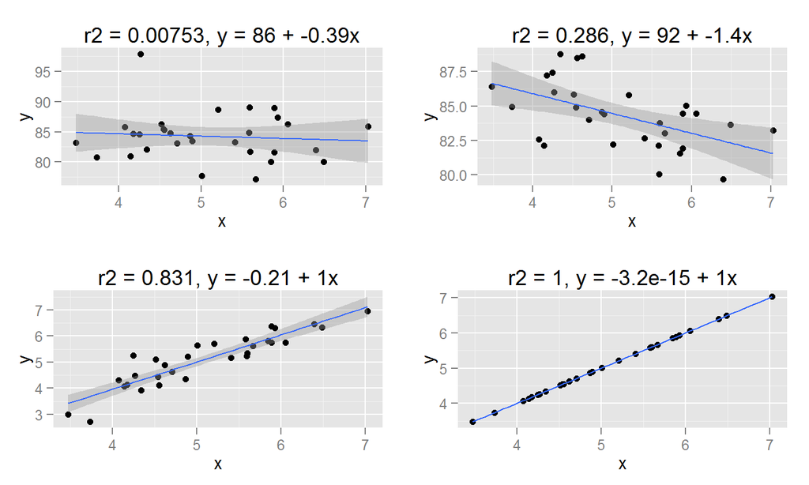

## Standard deviation about the least squares line

The **standard deviation about the least squares line** is denoted \(s_e\) and given by

\[s_e = \sqrt{\frac{SSResid}{n-2}}\]

\(s_e\) is interpreted as the "typical" amount by which an observation deviates from the least squares line.

## Nonlinear Relationships and Transformations

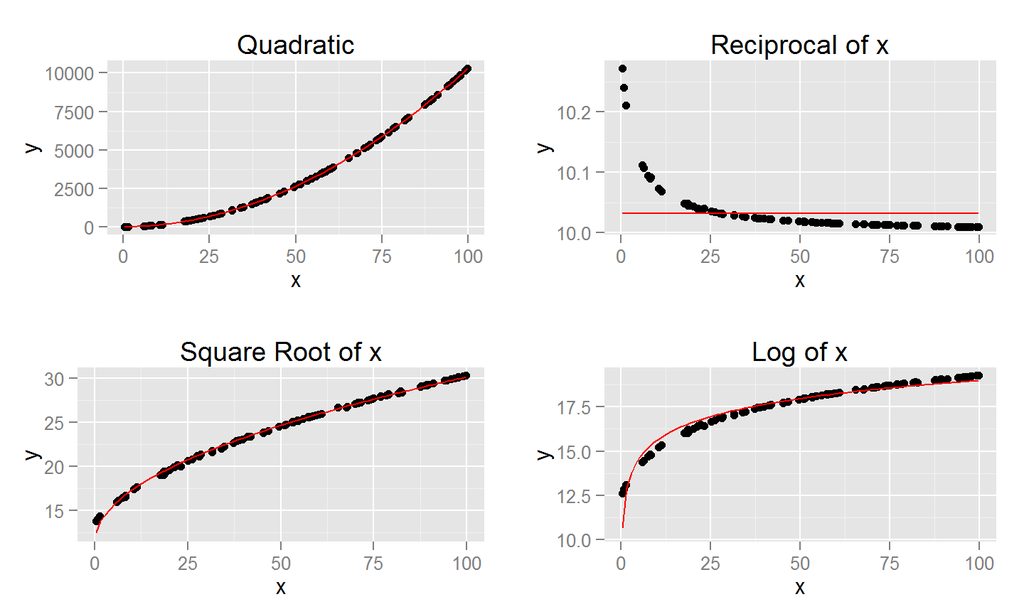

## Reciprical Transformation Example

[figure not shown]

## Regression for Bivariate Numeric Dataset

1. Summarize with scatterplot
2. Determine linear relationship
3. Find equation of least-squares regression line
4. Construct residual plot to look for patterns
5. Compare \(s_e\) and \(r^2\)
6. Decide if least-squares line is useful for predictions
7. Use regression line for prediction

## Homework Chapter 5

- 5.1, 5.2, 5.9,
- 5.15, 5.16, 5.26
- 5.29, 5.33, 5.47